# era5 data processing

In this notebook, we can see the complete netcdf to parquet processing. This is for demonstration purpose.

Please visit the [github depot](https://github.com/ludwigVonKoopa/s3-test) to see sources, functions used and a script doing the conversion pipeline.

## simple processing

We download the file and save it locally

```python
import xarray as xr
import boto3
import os

filename = "era5.nc"
if not os.path.exists(filename):
    s3 = boto3.client('s3')
    s3.download_file("era5-pds", "2022/05/data/precipitation_amount_1hour_Accumulation.nc", filename)

! ls -lah {filename}
ds = xr.open_dataset(filename)
```

```
-rw-r--r-- 1 clement clement 185M Nov 23 22:39 era5.nc
```

The file consist of hourly precipitations, globally arount the globe

```
<cartopy.mpl.geocollection.GeoQuadMesh at 0x7f18296b4940>
```

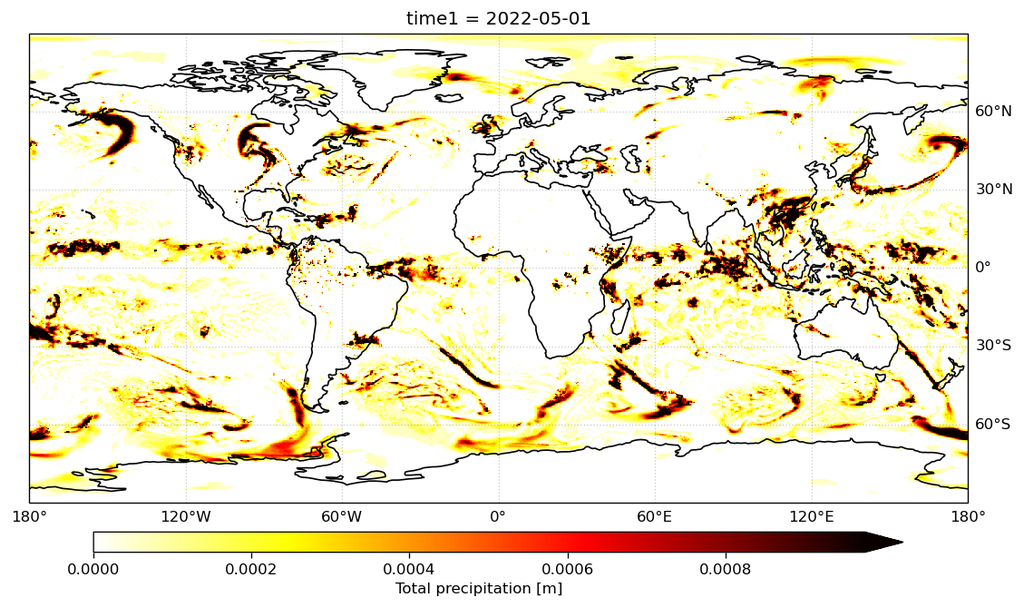

```python
import visu

fig, ax = visu.start_ax()
da = ds.precipitation_amount_1hour_Accumulation

da[0].plot(ax=ax, cmap="hot_r", robust=True, cbar_kwargs=dict(orientation="horizontal", shrink=0.8, aspect=40, pad=0.05))
```

## preprocessing

for simple processing, we delete useless coordinates and rename precipitation

```python
ds = ds.drop_vars("time1_bounds").rename(
    {"precipitation_amount_1hour_Accumulation": "precipitation", "time1": "time"}
)
ds
```

```
<xarray.Dataset>
Dimensions:        (lon: 1440, lat: 721, time: 744)
Coordinates:
  * lon            (lon) float32 0.0 0.25 0.5 0.75 ... 359.0 359.2 359.5 359.8
  * lat            (lat) float32 90.0 89.75 89.5 89.25 ... -89.5 -89.75 -90.0
  * time           (time) datetime64[ns] 2022-05-01 ... 2022-05-31T23:00:00
Data variables:
    precipitation  (time, lat, lon) float32 ...
Attributes:
    source:       Reanalysis
    institution:  ECMWF
    title:        ERA5 forecasts
```

As specified in the document, we add [h3 geospatial index](https://h3geo.org/docs/highlights/indexing/)

h3 indexing is available in `str` or `int` representation. I choose `int` h3 format, because of his nice compression properties.

```python
import processing

ds = processing.build_h3_indexes(ds, levels=[0,1,2,3], h3_type="int")
ds
```

```
<xarray.Dataset>
Dimensions:        (lon: 1440, lat: 721, time: 744)
Coordinates:
  * lon            (lon) float32 0.0 0.25 0.5 0.75 ... 359.0 359.2 359.5 359.8
  * lat            (lat) float32 90.0 89.75 89.5 89.25 ... -89.5 -89.75 -90.0
  * time           (time) datetime64[ns] 2022-05-01 ... 2022-05-31T23:00:00
Data variables:
    precipitation  (time, lat, lon) float32 ...
    h3_00          (lon, lat) int64 577094071001022463 ... 580155111372750847
    h3_01          (lon, lat) int64 581571282349326335 ... 584654312953610239
    h3_02          (lon, lat) int64 586073232709255167 ... 589154064290283519
    h3_03          (lon, lat) int64 590576420019765247 ... 593657595198177279
Attributes:
    source:       Reanalysis
    institution:  ECMWF
    title:        ERA5 forecasts
```

For demonstration and speed purpose, we reduce the dataset

```python
subset = ds.isel(time=slice(0, 48))
subset
```

```
<xarray.Dataset>
Dimensions:        (lon: 1440, lat: 721, time: 48)
Coordinates:
  * lon            (lon) float32 0.0 0.25 0.5 0.75 ... 359.0 359.2 359.5 359.8
  * lat            (lat) float32 90.0 89.75 89.5 89.25 ... -89.5 -89.75 -90.0
  * time           (time) datetime64[ns] 2022-05-01 ... 2022-05-02T23:00:00
Data variables:
    precipitation  (time, lat, lon) float32 ...
    h3_00          (lon, lat) int64 577094071001022463 ... 580155111372750847
    h3_01          (lon, lat) int64 581571282349326335 ... 584654312953610239
    h3_02          (lon, lat) int64 586073232709255167 ... 589154064290283519
    h3_03          (lon, lat) int64 590576420019765247 ... 593657595198177279
Attributes:
    source:       Reanalysis
    institution:  ECMWF
    title:        ERA5 forecasts
```

## conversion to parquet format

```python
parquet_file = "era5.parquet"
processing.ds_to_parquet(subset, parquet_file, dim_time="time")

! ls -lah {parquet_file}
```

```
-rw-r--r-- 1 clement clement 36M Nov 24 22:07 era5.parquet
```

```python
import pandas
pandas.read_parquet(parquet_file)
```

| time | lon | lat | precipitation | h3_00 | h3_01 | h3_02 | h3_03 |
| --- | --- | --- | --- | --- | --- | --- | --- |
| 2022-05-01 00:00:00 | 0.00 | 90.0 | 0.000061 | 577094071001022463 | 581571282349326335 | 586073232709255167 | 590576420019765247 |
| 2022-05-01 01:00:00 | 0.00 | 90.0 | 0.000000 | 577094071001022463 | 581571282349326335 | 586073232709255167 | 590576420019765247 |
| 2022-05-01 02:00:00 | 0.00 | 90.0 | 0.000000 | 577094071001022463 | 581571282349326335 | 586073232709255167 | 590576420019765247 |
| 2022-05-01 03:00:00 | 0.00 | 90.0 | 0.000061 | 577094071001022463 | 581571282349326335 | 586073232709255167 | 590576420019765247 |
| 2022-05-01 04:00:00 | 0.00 | 90.0 | 0.000122 | 577094071001022463 | 581571282349326335 | 586073232709255167 | 590576420019765247 |
| ... | ... | ... | ... | ... | ... | ... | ... |
| 2022-05-02 19:00:00 | 359.75 | -90.0 | 0.000061 | 580155111372750847 | 584654312953610239 | 589154064290283519 | 593657595198177279 |
| 2022-05-02 20:00:00 | 359.75 | -90.0 | 0.000061 | 580155111372750847 | 584654312953610239 | 589154064290283519 | 593657595198177279 |
| 2022-05-02 21:00:00 | 359.75 | -90.0 | 0.000061 | 580155111372750847 | 584654312953610239 | 589154064290283519 | 593657595198177279 |
| 2022-05-02 22:00:00 | 359.75 | -90.0 | 0.000061 | 580155111372750847 | 584654312953610239 | 589154064290283519 | 593657595198177279 |
| 2022-05-02 23:00:00 | 359.75 | -90.0 | 0.000000 | 580155111372750847 | 584654312953610239 | 589154064290283519 | 593657595198177279 |

49835520 rows × 7 columns

## upload to s3 bucket

```python
import os

# setup BUCKET_S3 variable or change it with your bucket name
BUCKET_S3 = os.environ["BUCKET_S3"]

s3_client = boto3.client('s3')
response = s3_client.upload_file(parquet_file, BUCKET_S3, parquet_file)
```

## basic query testing

```python
import boto3
from io import StringIO
import pandas

def query_sql_on_parquet(query, bucket_name, filename):
    s3 = boto3.client('s3')

    resp = s3.select_object_content(
        Bucket=bucket_name, Key=filename, ExpressionType='SQL', Expression=query,
        InputSerialization = {'Parquet': {}}, OutputSerialization = {'CSV': {"FieldDelimiter": ";"}},
    )

    records = ""
    stats = dict()

    for i, event in enumerate(resp['Payload']):
        if 'Records' in event:
            records = records + event['Records']['Payload'].decode('utf-8')

        elif 'Stats' in event:
            stats.update(event['Stats']['Details'])
        print(f"i={i:03d} : {len(records):09d} nbytes", end="\r")

    print()
    for k,v in stats.items():
        print(f"{k} = {v}")

    if len(records) > 1:
        df = pandas.read_csv(StringIO(records), sep=";", header=None)
    else:
        print("no data :(")
        df = None
    return df
```

```python
query = "SELECT s.\"time\", s.\"precipitation\" FROM s3object s LIMIT 100"
df_query = query_sql_on_parquet(query, BUCKET_S3, parquet_file)
df_query
```

```
i=002 : 000003837 nbytes
BytesScanned = 1806365
BytesProcessed = 31000
BytesReturned = 3837
```

|  | 0 | 1 |
| --- | --- | --- |
| 0 | 2022-05-01T00:00:00.000Z | 0.000061 |
| 1 | 2022-05-01T01:00:00.000Z | 0.000000 |
| 2 | 2022-05-01T02:00:00.000Z | 0.000000 |
| 3 | 2022-05-01T03:00:00.000Z | 0.000061 |
| 4 | 2022-05-01T04:00:00.000Z | 0.000122 |
| ... | ... | ... |
| 95 | 2022-05-01T05:00:00.000Z | 0.000061 |
| 96 | 2022-05-01T00:00:00.000Z | 0.000061 |
| 97 | 2022-05-01T01:00:00.000Z | 0.000061 |
| 98 | 2022-05-01T02:00:00.000Z | 0.000061 |
| 99 | 2022-05-01T03:00:00.000Z | 0.000061 |

100 rows × 2 columns

### query on time

```python
query = (
    "SELECT s.\"time\", s.\"precipitation\" FROM s3object s "
    "WHERE s.\"time\" BETWEEN CAST('2022-05-01T13:00:00Z' AS TIMESTAMP) AND CAST('2022-05-01T15:00:00Z' AS TIMESTAMP)"
)

df_query = query_sql_on_parquet(query, BUCKET_S3, parquet_file)
df_query
```

```
i=1596 : 101229908 nbytes
BytesScanned = 14902280
BytesProcessed = 1544901120
BytesReturned = 101229908
```

|  | 0 | 1 |
| --- | --- | --- |
| 0 | 2022-05-01T13:00:00.000Z | 0.0 |
| 1 | 2022-05-01T14:00:00.000Z | 0.0 |
| 2 | 2022-05-01T15:00:00.000Z | 0.0 |
| 3 | 2022-05-01T13:00:00.000Z | 0.0 |
| 4 | 2022-05-01T14:00:00.000Z | 0.0 |
| ... | ... | ... |
| 3114715 | 2022-05-01T14:00:00.000Z | 0.0 |
| 3114716 | 2022-05-01T15:00:00.000Z | 0.0 |
| 3114717 | 2022-05-01T13:00:00.000Z | 0.0 |
| 3114718 | 2022-05-01T14:00:00.000Z | 0.0 |
| 3114719 | 2022-05-01T15:00:00.000Z | 0.0 |

3114720 rows × 2 columns

### query on geo pos

```python
import h3.api.basic_int as h3
lat = 43.600378
lon = 1.445478
h3_index = h3.geo_to_h3(lat, lng=lon, resolution=2)
h3_index
```

```
586477852988276735
```

```python
query = f"SELECT s.\"time\", s.\"precipitation\" FROM s3object s WHERE s.\"h3_02\" = {h3_index}"
print(query)

df_query = query_sql_on_parquet(query, BUCKET_S3, parquet_file)
df_query
```

```
SELECT s."time", s."precipitation" FROM s3object s WHERE s."h3_02" = 586477852988276735
i=018 : 000243530 nbytes
BytesScanned = 17110632
BytesProcessed = 2192762880
BytesReturned = 243530
```

|  | 0 | 1 |
| --- | --- | --- |
| 0 | 2022-05-01T00:00:00.000Z | 0.000122 |
| 1 | 2022-05-01T01:00:00.000Z | 0.000061 |
| 2 | 2022-05-01T02:00:00.000Z | 0.000061 |
| 3 | 2022-05-01T03:00:00.000Z | 0.000000 |
| 4 | 2022-05-01T04:00:00.000Z | 0.000000 |
| ... | ... | ... |
| 7195 | 2022-05-02T19:00:00.000Z | 0.000122 |
| 7196 | 2022-05-02T20:00:00.000Z | 0.000122 |
| 7197 | 2022-05-02T21:00:00.000Z | 0.000061 |
| 7198 | 2022-05-02T22:00:00.000Z | 0.000061 |
| 7199 | 2022-05-02T23:00:00.000Z | 0.000061 |

7200 rows × 2 columns